# Pilot 2 analysis

Bonan Zhao

11/22/2021

# Experiment

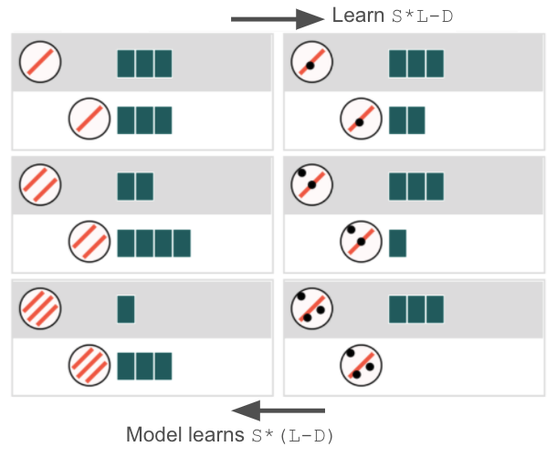

# Self-report labels

No one reported the model ground truth - as people tend to report just the multiplication sub-parts in learning phase B. In contrast, in Experiment 1 “combine” condition, about one third of people used phrases like “and then”, “on top of that” to report the model ground truth.

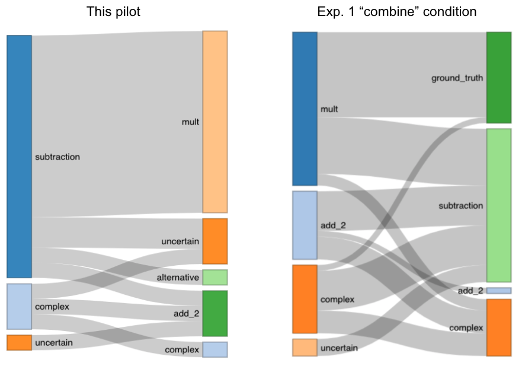

# Generalization accuracy

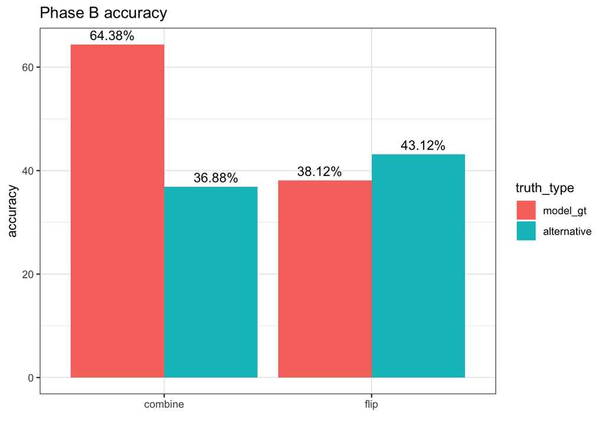

However the above accuracy measure can’t distinguish the model-truthers and alternative-truthers from those uncertain/add_2/complex guessers.

To have a better comparison, let’s define three types of generalization predictions (all conducted in Phase B generalization predictions):

- Model ground truth (model_gt): more than half of predictions in line with model ground truth
- Alternative: more than half of predictions in line with alternative truth
- Guessing: accuracy below 50%

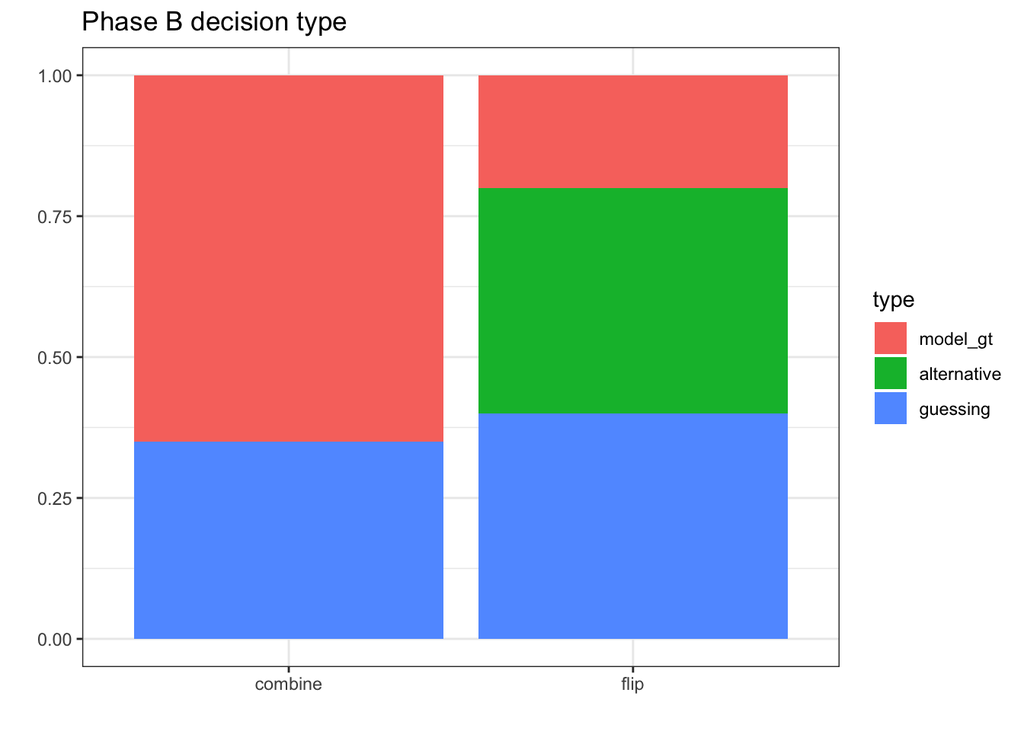